# Laboratorio 3

Oliver Mazariegos, Rafael Leon y Alejandro Vasquez

19/09/2018

# Analisis exploratorio

## Frecuencia de etiquetas

Veamos que etiquetas hay y cual es su frecuencia.

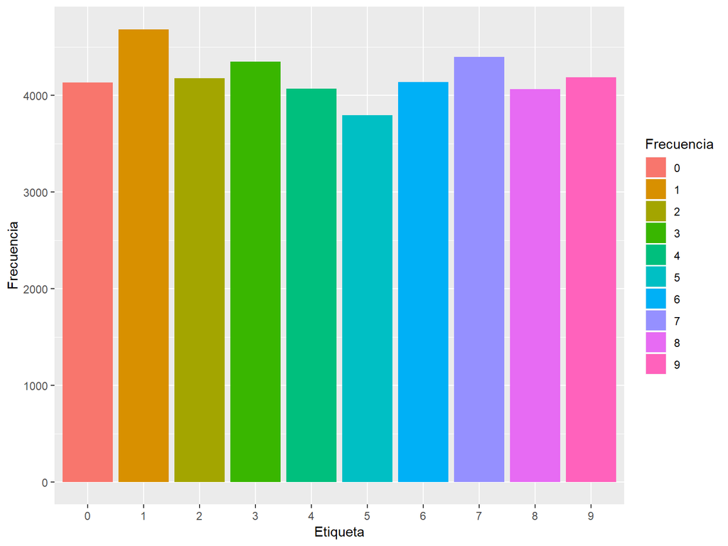

```r
cuantasLabels = as.data.frame(table(train$label))
ggplot(data = cuantasLabels, aes(x = Var1, y = Freq, fill = Var1)) + geom_bar(stat="identity") + labs(x = "Etiqueta", y = "Frecuencia", fill = "Frecuencia")
```

## Rtsne

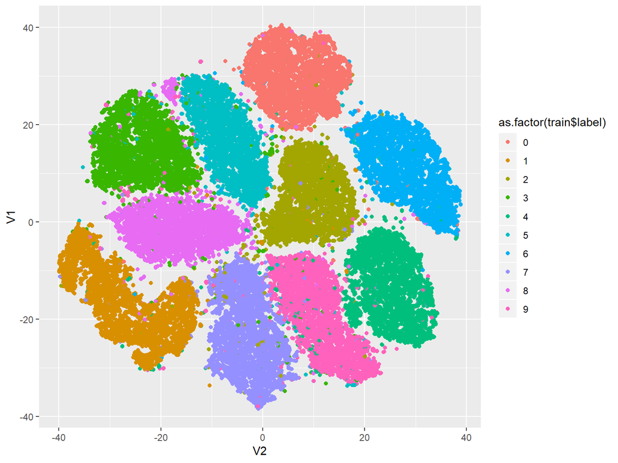

```r
set.seed(0)
tsneaOut = Rtsne(train[,c(2:785)])
redimension = as.data.frame(tsneaOut$Y)
ggplot(data = redimension, aes(x = V2, y = V1, col = as.factor(train$label))) + geom_point()
```

Efectivamente se puede notar que los datos se agrupan muy bien y en diez grupos distinos, lo cual es la cantidad de distintas clases. Esto significa que podriamos hacer una prediccion utilizando los pixeles de cada una de las imagenes o con la redimension de estos.

# Modelo de Redes Neuronales Simple

Se hizo un modelo secuencial de keras (libreria de Python), luego se “aplanan” (funcion “Flatten”) los datos para modificar la dimensionalidad de los datos. Despues, se generaron 128 nodos con la funcion “Dense”, utilizando el parametro “relu” que deciden las categorias a las que se clasificara cada dato. A este modelo, luego se le generaron 10 nuevos nodos con las categorias decididas anteriormente (hecho con “Dense”" y el parametro “softmax”). Por ?ltimo, el modelo fue compilado y ajustado a los datos, utilizando, primero 10 “epochs” (no presentados aqu?) y luego 5 “epochs”.

```python
import numpy as np
import tensorflow as tf
from tensorflow.python.keras.models import Sequential
from tensorflow.python.keras.layers import Dense, Dropout, Activation, Flatten
from tensorflow.python.keras.utils import to_categorical
from tensorflow.python.keras.datasets import mnist

(training_data, training_labels), (testing_data, testing_labels) = mnist.load_data()

# 5. Preprocess input data
training_data = training_data.astype('float32')
testing_data = testing_data.astype('float32')
training_data /= 255
testing_data /= 255

# 6. Preprocess class labels
training_labels = to_categorical(training_labels, 10)
testing_labels = to_categorical(testing_labels, 10)

# 7. Define model architecture
model = Sequential()

model.add(Flatten(input_shape = (28, 28)))
model.add(Dense(128, activation='relu'))
model.add(Dense(10, activation='softmax'))

# # 8. Compile model
model.compile(loss='categorical_crossentropy',
               optimizer='adam',
               metrics=['accuracy'])

# # 9. Fit model on training data
model.fit(training_data, training_labels,
           batch_size=32, epochs=5, verbose=0)

# # 10. Evaluate model on test data
print("VALIDATE MODEL")
```

```
## VALIDATE MODEL
```

```python
(loss, accuracy) =  model.evaluate(testing_data, testing_labels)
print('Test loss:', loss)
```

```
## Test loss: 0.07649395772763527
```

```python
print('Test accuracy:', accuracy)
```

```
## Test accuracy: 0.977
```

# Modelo de Deep Learning

Sea realizo un modelo de aprendizaje de maquina utilizando redes neuronales convolucionadas. Este se realizo en python utilizando tensorflow y keras.

```python
#Author Rafael Leon
#Example based onhttps://elitedatascience.com/keras-tutorial-deep-learning-in-python
import numpy as np
import tensorflow as tf
from tensorflow.python.keras.models import Sequential
from tensorflow.python.keras.layers import Dense, Dropout, Activation, Flatten
from tensorflow.python.keras.layers import Convolution2D, MaxPooling2D
from tensorflow.python.keras.utils import to_categorical
from tensorflow.python.keras.datasets import mnist

(training_data, training_labels), (testing_data, testing_labels) = mnist.load_data()

# 5. Preprocess input data
training_data = training_data.reshape(60000, 1, 28, 28)
#print(training_data.shape)
testing_data = testing_data.reshape(10000, 1, 28, 28)
#print(testing_data.shape)
training_data = training_data.astype('float32')
testing_data = testing_data.astype('float32')
training_data /= 255
testing_data /= 255

# 6. Preprocess class labels
training_labels = to_categorical(training_labels, 10)
testing_labels = to_categorical(testing_labels, 10)

# 7. Define model architecture
model = Sequential()

model.add(Convolution2D(32, 1, 1, activation='relu', input_shape=(1,28,28)))
model.add(Convolution2D(32, 1, 1, activation='relu'))
model.add(MaxPooling2D(pool_size=(1,1)))
model.add(Dropout(0.25))

model.add(Flatten())
model.add(Dense(128, activation='relu'))
model.add(Dropout(0.5))
model.add(Dense(10, activation='softmax'))

# # 8. Compile model
model.compile(loss='categorical_crossentropy',
               optimizer='adam',
               metrics=['accuracy'])

# # 9. Fit model on training data
model.fit(training_data, training_labels,
           batch_size=32, epochs=10, verbose=0)

# # 10. Evaluate model on test data
print("VALIDATE MODEL")
```

```
## VALIDATE MODEL
```

```python
(loss, accuracy) =  model.evaluate(testing_data, testing_labels)
print('Test loss:', loss)
```

```
## Test loss: 0.0640096029849432
```

```python
print('Test accuracy:', accuracy)
```

```
## Test accuracy: 0.9806
```

# Algoritmos Convencionales

```r
porcentaje<-0.7
set.seed(09876984)
corte <- sample(nrow(redimension),nrow(redimension)*porcentaje)
redimension = cbind(redimension, train$label)
colnames(redimension)[3] = "label"
redimension$label = as.factor(redimension$label)
trainSet<-redimension[corte,]
testSet<-redimension[-corte,]
```

## Support Vector Machine

Support Vector Machines, (SVM) son un conjunto de algoritmos de aprendizaje supervisado desarrollados por Vladimir Vapnik y su equipo en los laboratorios AT&T.

Estos metodos estan propiamente relacionados con problemas de clasificacion y regresion.

Intentaremos clasificar con SVM la etiqueta de los sets de pixeles utilizando la redimension de Tsne.

### Lineal

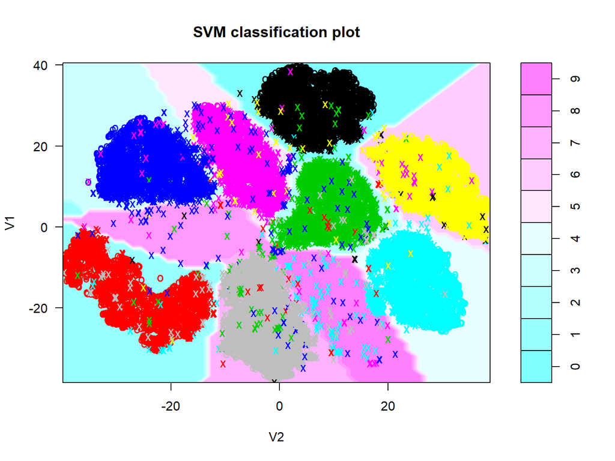

```r
set.seed(1)
model <- svm(label~. ,data=trainSet,kernel = "linear")
plot(model,trainSet, fill = trainSet$label)
```

```r
prediccion <- predict(model,testSet)


cfmSVM<-confusionMatrix(as.factor(prediccion),as.factor(testSet$label))

cfmSVM
```

```
## Confusion Matrix and Statistics
##
##           Reference
## Prediction    0    1    2    3    4    5    6    7    8    9
##          0 1165    0    4    1    1    2    9    0    4    1
##          1    0 1426    5    3    7    0    0    8   15    5
##          2    2    5 1201   11    0    1    0    6    4    2
##          3    1    0    1 1206    0   10    0    1   17   20
##          4    0    2    1    0 1062    0    2    2    2    8
##          5    1    0    0   36    0 1130    4    0   55    8
##          6    3    4    3    0    4    8 1245    0    4    1
##          7    0    0   14    4    1    2    0 1301    6   16
##          8    0    6    2   18    1    2    0    1 1169    6
##          9    0    0    3   12   92    5    0   26    6 1179
##
## Overall Statistics
##
##                Accuracy : 0.959
##                  95% CI : (0.9554, 0.9624)
##     No Information Rate : 0.1145
##     P-Value [Acc > NIR] : < 2.2e-16
##
##                   Kappa : 0.9544
##  Mcnemar's Test P-Value : NA
##
## Statistics by Class:
##
##                      Class: 0 Class: 1 Class: 2 Class: 3 Class: 4 Class: 5
## Sensitivity           0.99403   0.9882  0.97326  0.93416  0.90925  0.97414
## Specificity           0.99808   0.9961  0.99727  0.99558  0.99851  0.99091
## Pos Pred Value        0.98147   0.9707  0.97484  0.96019  0.98424  0.91572
## Neg Pred Value        0.99939   0.9985  0.99710  0.99251  0.99080  0.99736
## Prevalence            0.09301   0.1145  0.09793  0.10245  0.09269  0.09206
## Detection Rate        0.09245   0.1132  0.09531  0.09571  0.08428  0.08968
## Detection Prevalence  0.09420   0.1166  0.09777  0.09967  0.08563  0.09793
## Balanced Accuracy     0.99605   0.9922  0.98527  0.96487  0.95388  0.98252
##                      Class: 6 Class: 7 Class: 8 Class: 9
## Sensitivity           0.98810   0.9673  0.91186  0.94623
## Specificity           0.99762   0.9962  0.99682  0.98732
## Pos Pred Value        0.97877   0.9680  0.97012  0.89116
## Neg Pred Value        0.99868   0.9961  0.99008  0.99406
## Prevalence            0.09999   0.1067  0.10174  0.09888
## Detection Rate        0.09880   0.1032  0.09277  0.09356
## Detection Prevalence  0.10094   0.1067  0.09563  0.10499
## Balanced Accuracy     0.99286   0.9817  0.95434  0.96677
```

### Radial

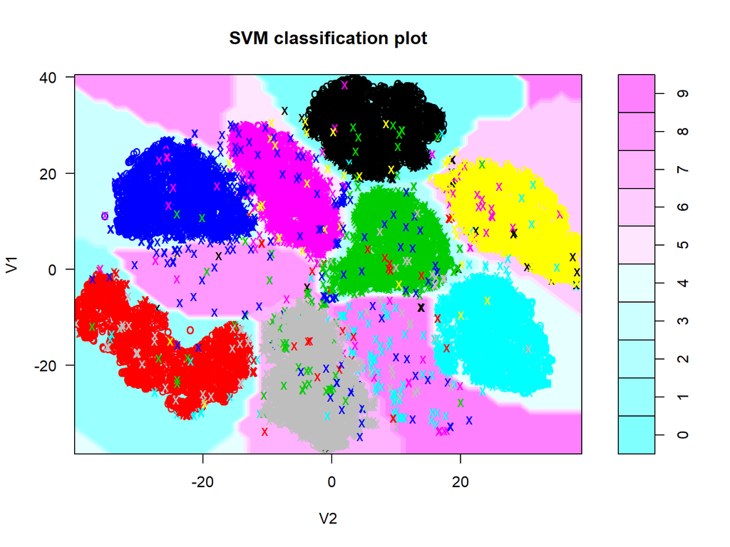

```r
set.seed(2)
model <- svm(label~. ,data=trainSet,kernel = "radial")
plot(model,trainSet, fill = trainSet$label)
```

```r
prediccion <- predict(model,testSet)


cfmSVM<-confusionMatrix(as.factor(prediccion),as.factor(testSet$label))

cfmSVM
```

```
## Confusion Matrix and Statistics
##
##           Reference
## Prediction    0    1    2    3    4    5    6    7    8    9
##          0 1165    0    3    1    1    2    8    0    4    1
##          1    0 1431    6    3    7    0    0    8    7    4
##          2    2    5 1202   15    0    1    0    6    4    1
##          3    1    0    1 1211    0   10    0    1   17   20
##          4    0    2    1    0 1106    0    2    3    2    8
##          5    1    0    0   30    0 1131    3    0   18    8
##          6    3    4    3    0    4    8 1246    0    4    1
##          7    0    0   15    4    1    2    0 1305    6   19
##          8    0    1    1   20    1    1    1    0 1215    6
##          9    0    0    2    7   48    5    0   22    5 1178
##
## Overall Statistics
##
##                Accuracy : 0.9674
##                  95% CI : (0.9641, 0.9704)
##     No Information Rate : 0.1145
##     P-Value [Acc > NIR] : < 2.2e-16
##
##                   Kappa : 0.9637
##  Mcnemar's Test P-Value : NA
##
## Statistics by Class:
##
##                      Class: 0 Class: 1 Class: 2 Class: 3 Class: 4 Class: 5
## Sensitivity           0.99403   0.9917  0.97407   0.9380  0.94692  0.97500
## Specificity           0.99825   0.9969  0.99701   0.9956  0.99843  0.99476
## Pos Pred Value        0.98312   0.9761  0.97249   0.9603  0.98399  0.94962
## Neg Pred Value        0.99939   0.9989  0.99718   0.9929  0.99460  0.99746
## Prevalence            0.09301   0.1145  0.09793   0.1025  0.09269  0.09206
## Detection Rate        0.09245   0.1136  0.09539   0.0961  0.08777  0.08975
## Detection Prevalence  0.09404   0.1163  0.09809   0.1001  0.08920  0.09452
## Balanced Accuracy     0.99614   0.9943  0.98554   0.9668  0.97267  0.98488
##                      Class: 6 Class: 7 Class: 8 Class: 9
## Sensitivity           0.98889   0.9703  0.94774  0.94543
## Specificity           0.99762   0.9958  0.99726  0.99216
## Pos Pred Value        0.97879   0.9652  0.97512  0.92976
## Neg Pred Value        0.99876   0.9964  0.99410  0.99400
## Prevalence            0.09999   0.1067  0.10174  0.09888
## Detection Rate        0.09888   0.1036  0.09642  0.09348
## Detection Prevalence  0.10102   0.1073  0.09888  0.10055
## Balanced Accuracy     0.99325   0.9830  0.97250  0.96879
```

Gracias a la reduccion de dimensiones de Tsne se pudo utilizar support vector machine (SVM) con un kernel radial logrando un accuaracy del 96%. El kerner radial supero al kernel lineal ya que los grupos no pueden separarse por lineas o por patrones senoidales de una manera tan precisa, pero de forma radial si (recordemos del grafico de tsne que los grupos tenian formas de islas o cicunferencias). En el grafico de clasificacion del SVM se puede ver que los datos mal clasificados son los puntos de otra etiqueta/numero que caen sobre otro grupo.

## Arbol de Decision

Los arboles de decision es un modelo de prediccion. Dado un conjunto de datos se fabrican diagramas de construcciones l?gicas, muy similares a los sistemas de predicci?n basados en reglas, que sirven para representar y categorizar una serie de condiciones que ocurren de forma sucesiva, para la resoluci?n de un problema.

En nuestro caso, imagenes de numeros, se espera que si cumple ciertas condiciones, las imagenes representan una etiqueta en especifico. Utilizaremos la matriz reducida por Tsne para hacer la clasificacion.

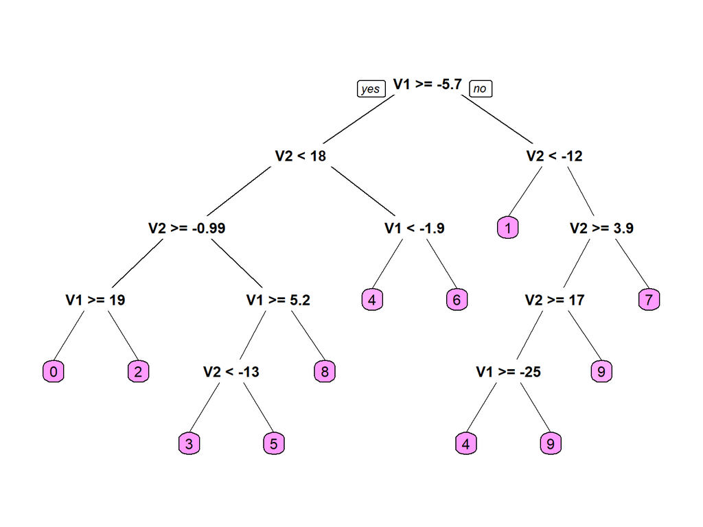

```r
library(rpart)
library(rpart.plot)
set.seed(0987)
dt_model<-rpart(label~.,trainSet,method = "class")
prp(dt_model,box.palette="Pu")
```

```r
prediccion <- predict(dt_model, newdata = testSet)
columnaMasAlta<-apply(prediccion, 1, function(x) colnames(prediccion)[which.max(x)])
prediccion<-as.factor(columnaMasAlta)

#Matriz de confusion

cfmDT<-confusionMatrix(prediccion,testSet$label)
cfmDT
```

```
## Confusion Matrix and Statistics
##
##           Reference
## Prediction    0    1    2    3    4    5    6    7    8    9
##          0 1084    0    3    0    1    2   13    0    7    1
##          1    0 1315    4    6    4    0    0    8  123    3
##          2    1    5 1188   26    0   92   11    6    1    1
##          3    1    0    1 1197    0   91    2    1   61   21
##          4    0    0    1    0 1072    0   16    2    1   21
##          5   82    0    0   32    0  922    4    0   11    7
##          6    3    4   15    0   15    6 1214    0    4    1
##          7    0    0   15   10   11    1    0 1280   17   95
##          8    1  117    5   13    2   40    0    0 1051    7
##          9    0    2    2    7   63    6    0   48    6 1089
##
## Overall Statistics
##
##                Accuracy : 0.9056
##                  95% CI : (0.9004, 0.9107)
##     No Information Rate : 0.1145
##     P-Value [Acc > NIR] : < 2.2e-16
##
##                   Kappa : 0.8951
##  Mcnemar's Test P-Value : NA
##
## Statistics by Class:
##
##                      Class: 0 Class: 1 Class: 2 Class: 3 Class: 4 Class: 5
## Sensitivity           0.92491   0.9113  0.96272  0.92719  0.91781  0.79483
## Specificity           0.99764   0.9867  0.98742  0.98426  0.99641  0.98811
## Pos Pred Value        0.97570   0.8988  0.89256  0.87055  0.96316  0.87146
## Neg Pred Value        0.99234   0.9885  0.99592  0.99163  0.99164  0.97938
## Prevalence            0.09301   0.1145  0.09793  0.10245  0.09269  0.09206
## Detection Rate        0.08602   0.1044  0.09428  0.09499  0.08507  0.07317
## Detection Prevalence  0.08817   0.1161  0.10563  0.10912  0.08833  0.08396
## Balanced Accuracy     0.96128   0.9490  0.97507  0.95572  0.95711  0.89147
##                      Class: 6 Class: 7 Class: 8 Class: 9
## Sensitivity           0.96349   0.9517  0.81981  0.87400
## Specificity           0.99577   0.9868  0.98366  0.98820
## Pos Pred Value        0.96197   0.8957  0.85032  0.89043
## Neg Pred Value        0.99594   0.9942  0.97967  0.98620
## Prevalence            0.09999   0.1067  0.10174  0.09888
## Detection Rate        0.09634   0.1016  0.08341  0.08642
## Detection Prevalence  0.10015   0.1134  0.09809  0.09706
## Balanced Accuracy     0.97963   0.9692  0.90173  0.93110
```

# Comparacion de Algoritmos

- De los algoritmos de aprendizaje de maquina convencionales, el SVM (usando un kernel radial) es mas preciso que los arboles de decision.
- El algoritmo de Redes Neuronales simple es mas poderoso que los modelos tradicionales y no difiere mucho del modelo de redes neuronales convolucionadas *El mejor modelo de los tres es el modelo de Redes Neuronales Convolucionadas.